# Tarea 4 Inferencia Estadística

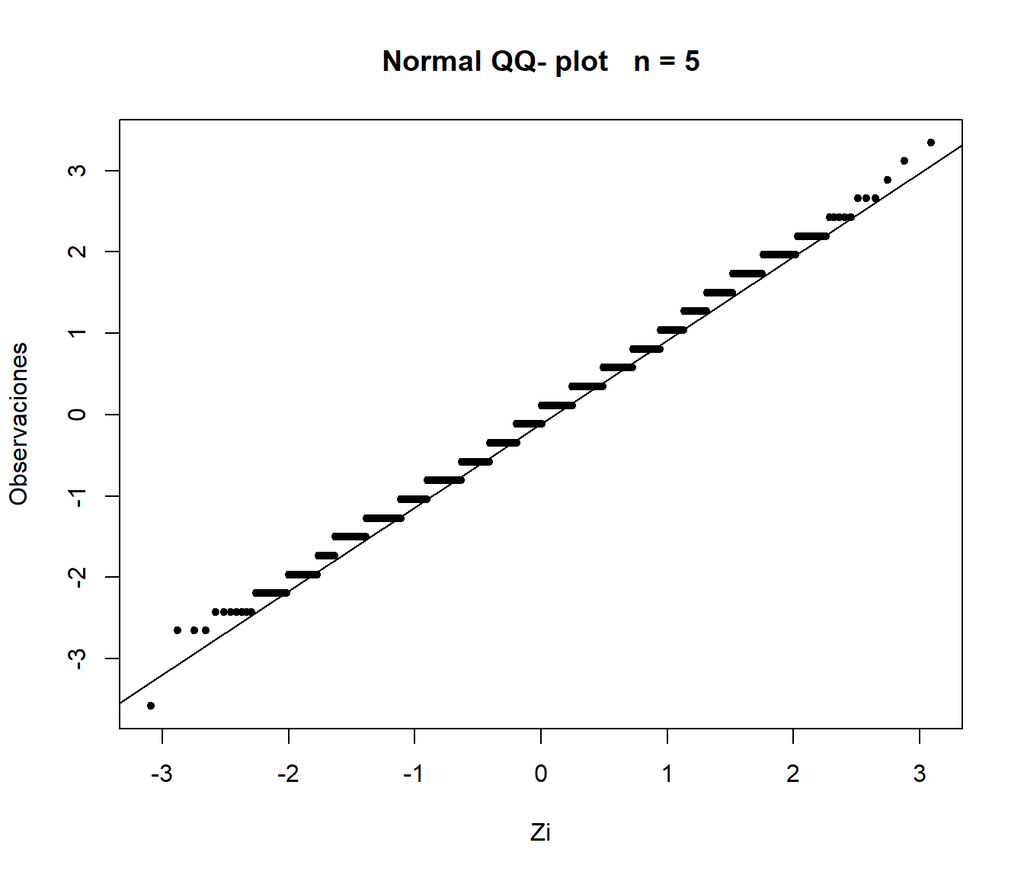

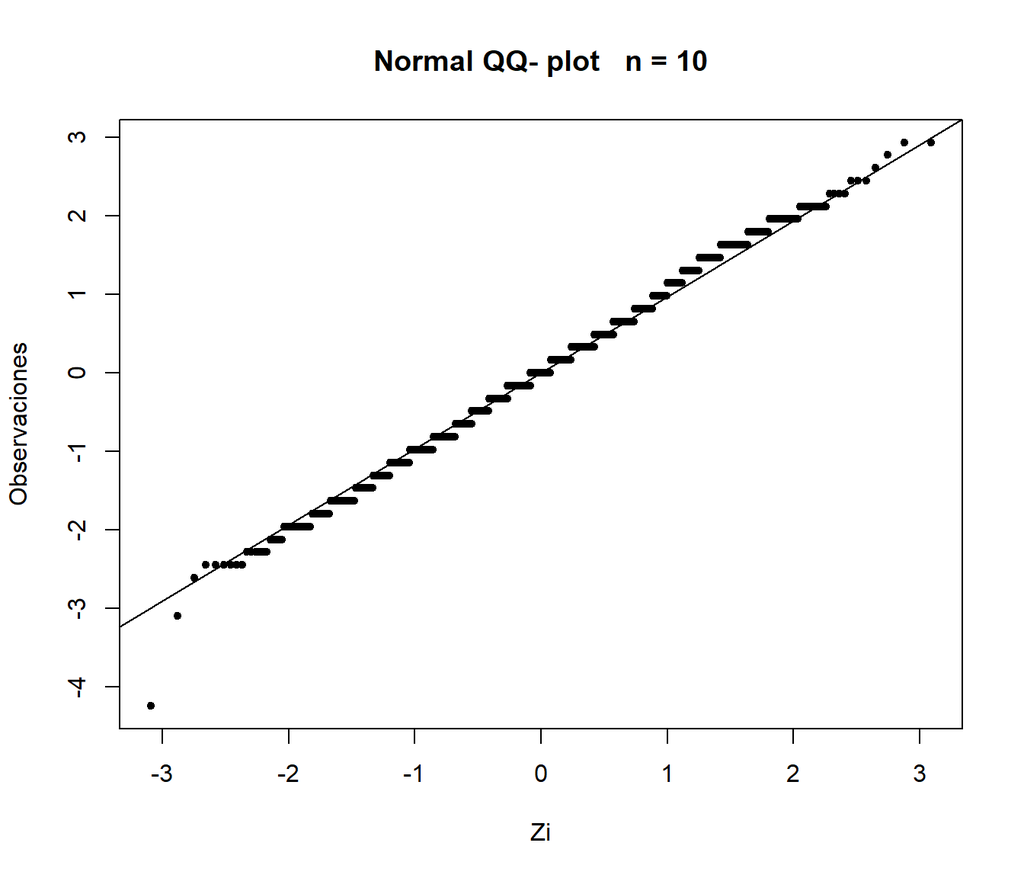

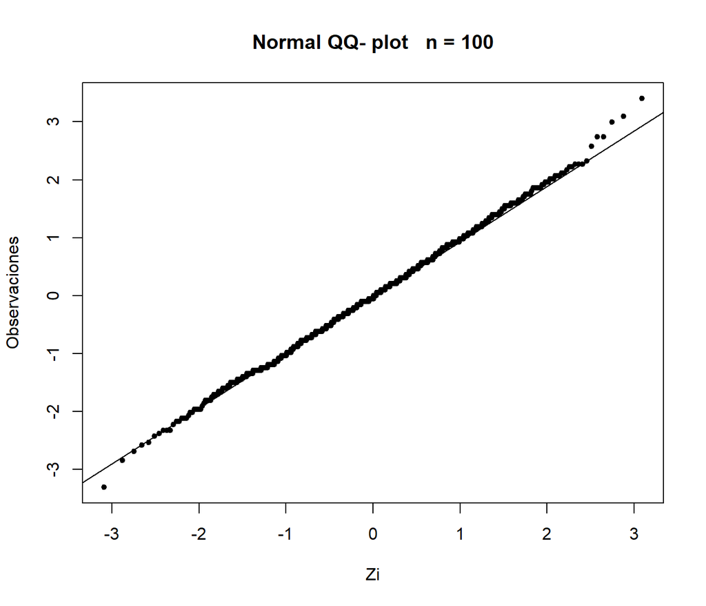

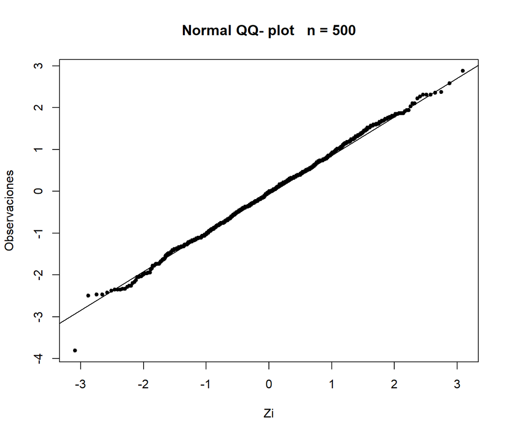

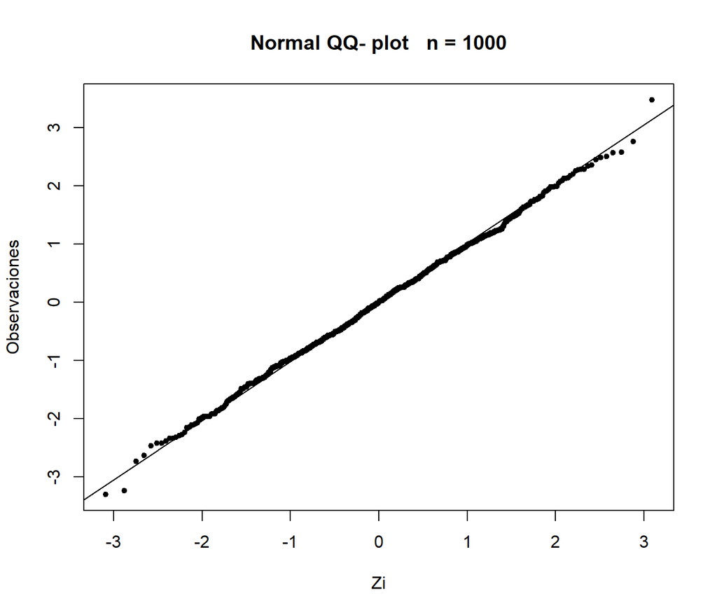

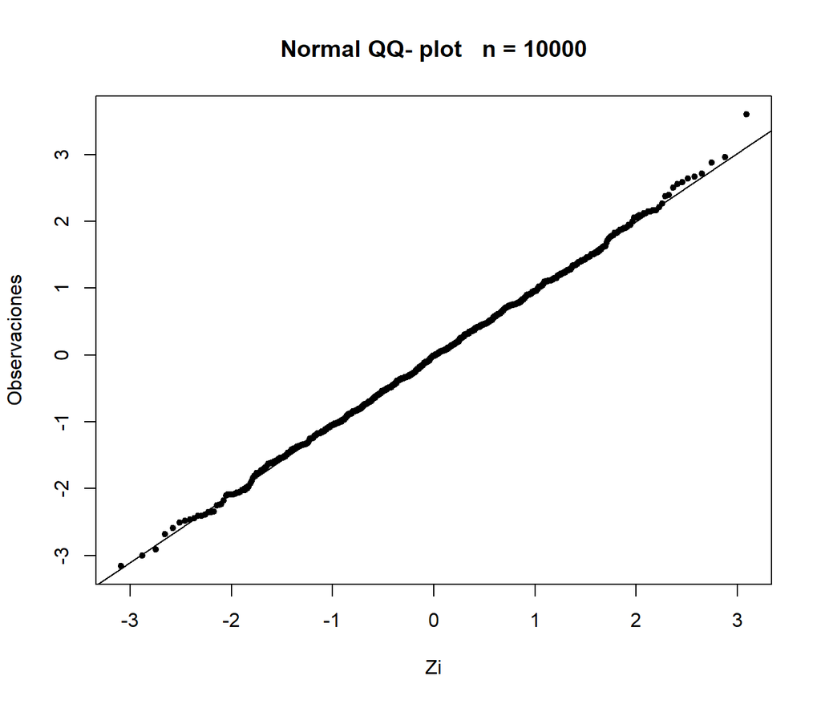

```r
i <- 1:6
auxiliar2 <- sapply(i, function(i) qqplotFunction(Muestra[ ,i], n[i]) )
```

Al realizar el QQ-plot de la distribución binomial, se observa que con un tamaño de muestra pequeño (n = 5), la distribución estimada se aproxima al centro de la teoríca. Una vez incrementando el número de muestra, se puede ver que el efecto de escalonamiento -debido a que es una variable aleatoria discreta- pasa a haacer algo más apriximado a lo continuo, dejando más apreciable como el teoréma del límite central se cumple, haciendo que la sucesión de binomiales al estandarizarlas y tomar límite llevando la muesra al infinito converge en distribución a una normal estandar.

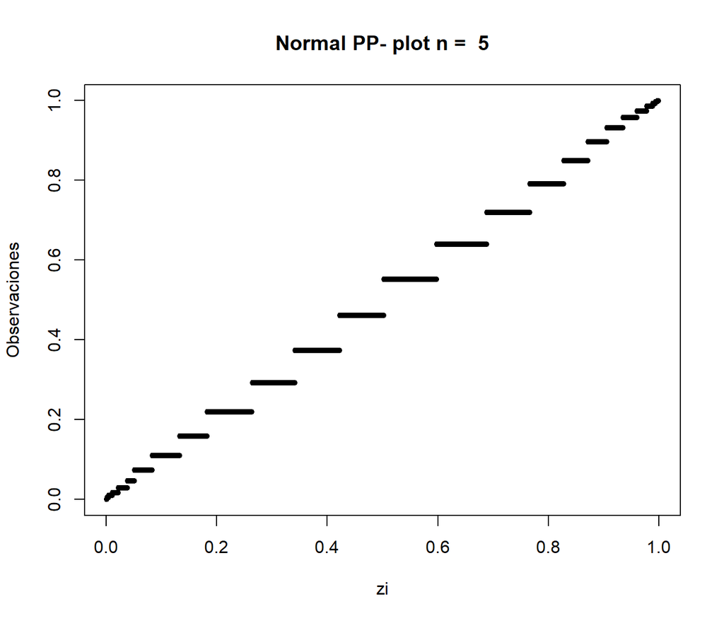

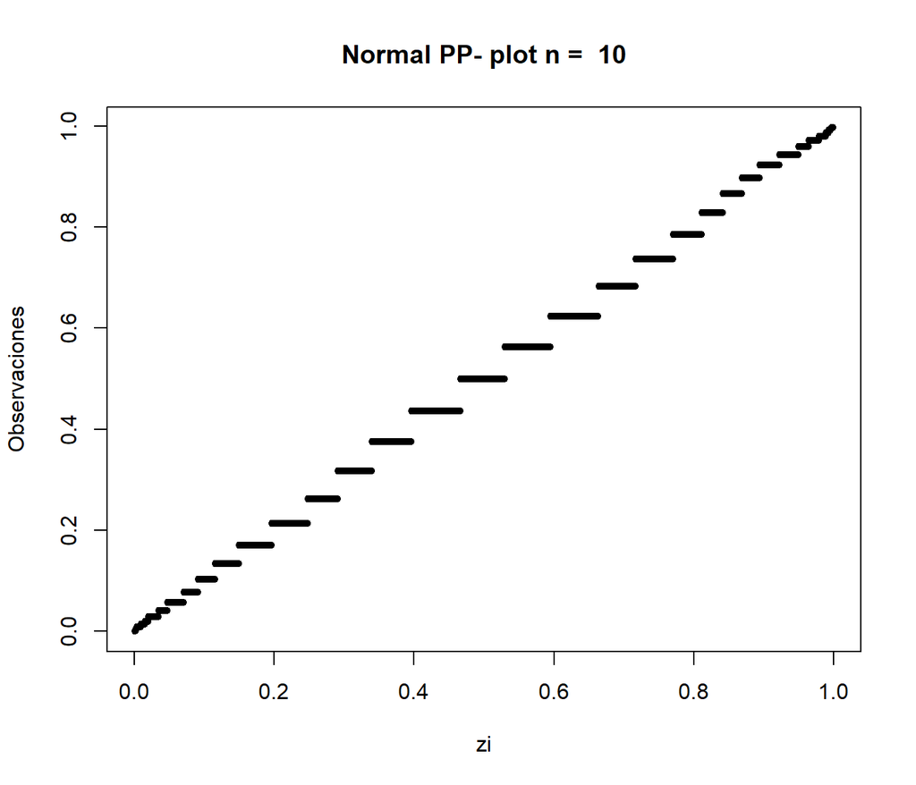

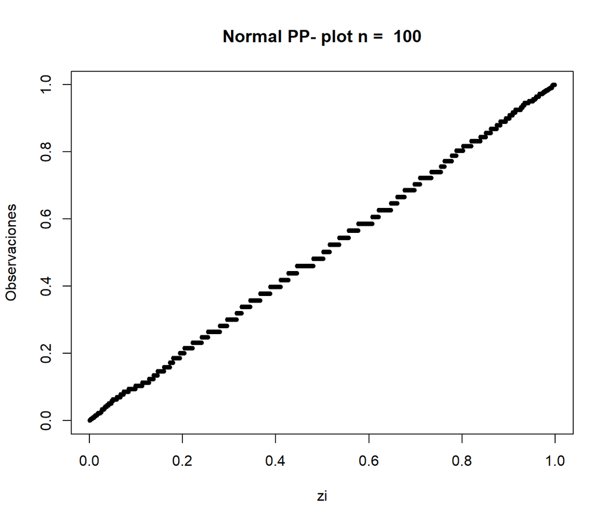

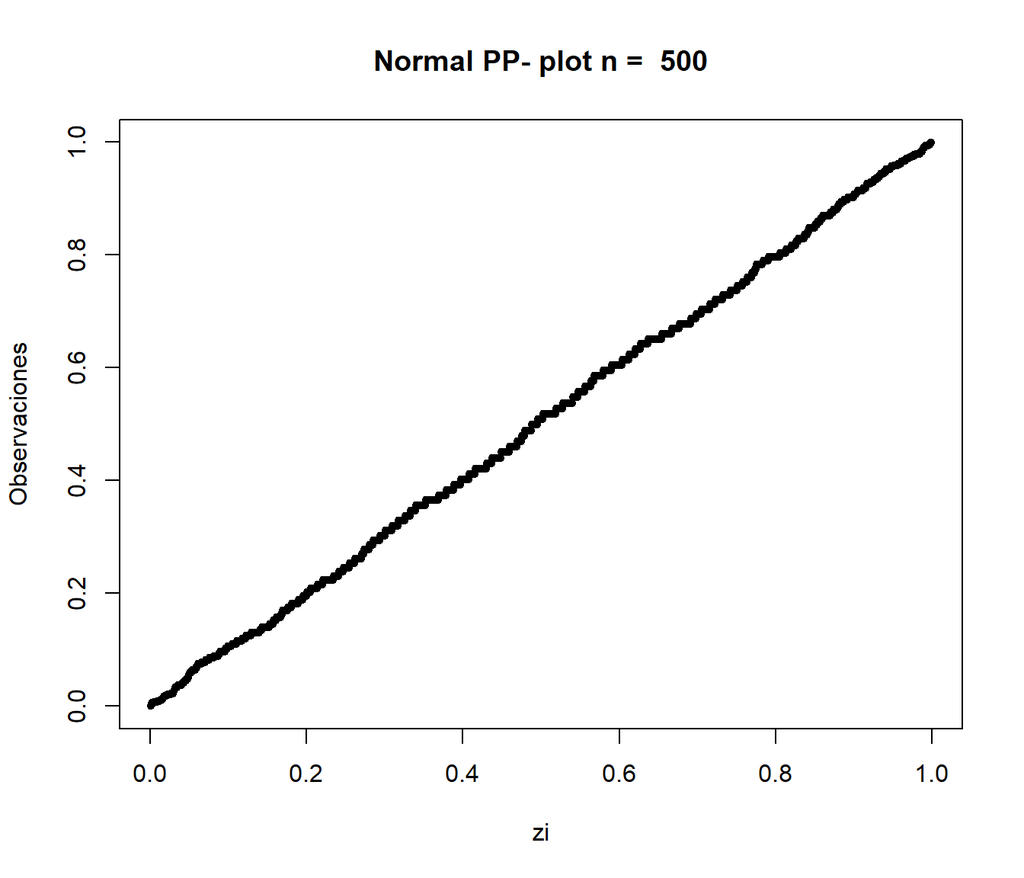

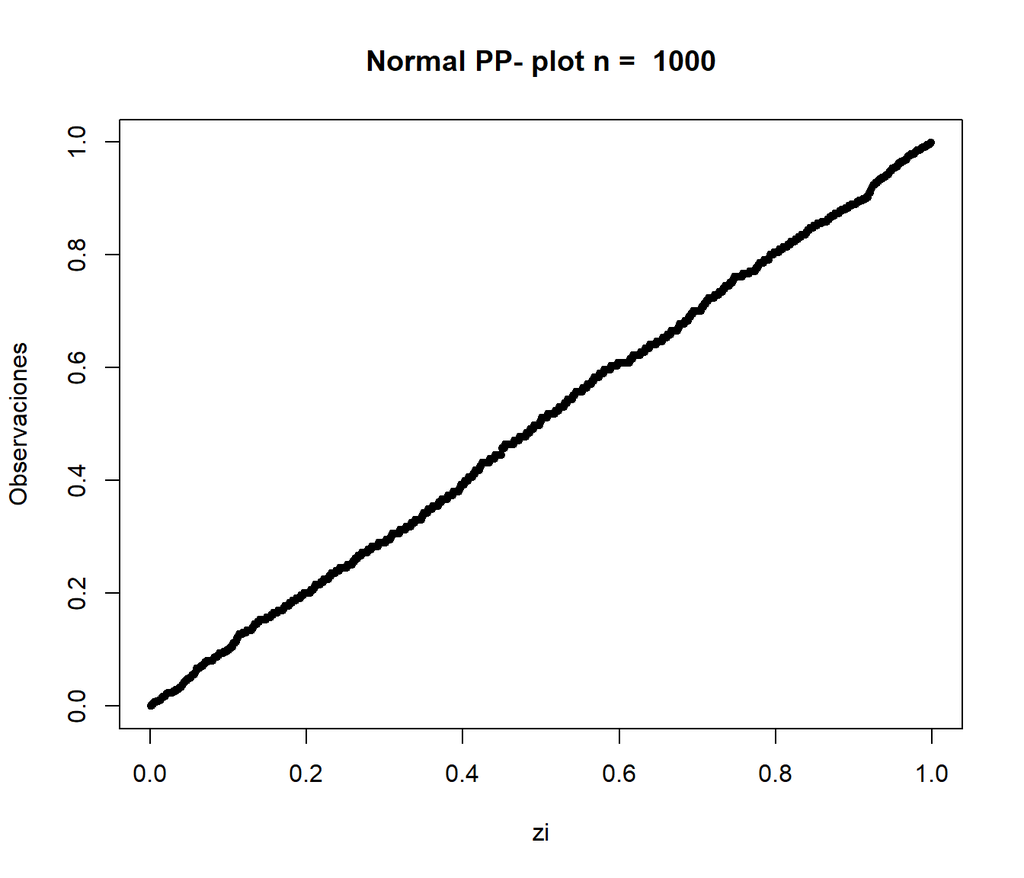

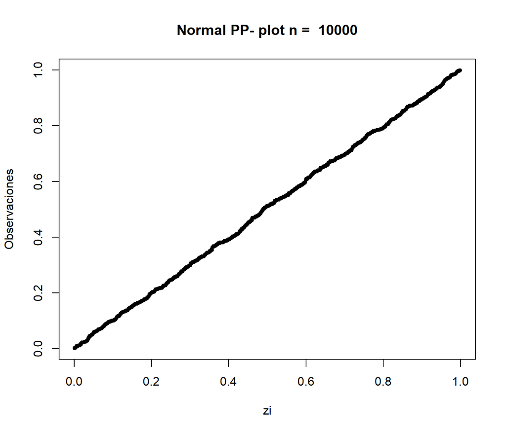

```r
pp_plotFunction(Muestra[ , 1], n[1])
i <- 1:6
  auxiliar3 <- sapply(i, function(i) pp_plotFunction(Muestra[ ,i], n[i]) )
```

En el caso del PP- plot, presenta un comportamiento similar a lo presentado con el gráfico de QQ-plot. Estó es, que bajo muestras pequeñas se observa que el contraste de las probabilidades empiricas y teorícas rondan sobre la normal, peros es hasta que el número de muestra incrementa cuando se aprecia lo anterior mencionado.

3. Para p = 0.1, N = 15, n = 5; 10; 20; 100 y m = 1000, genere muestras de Zn y grafíque estás muestras en un histograma (un histograma para cada n). ¿Qué observa? Explíque.

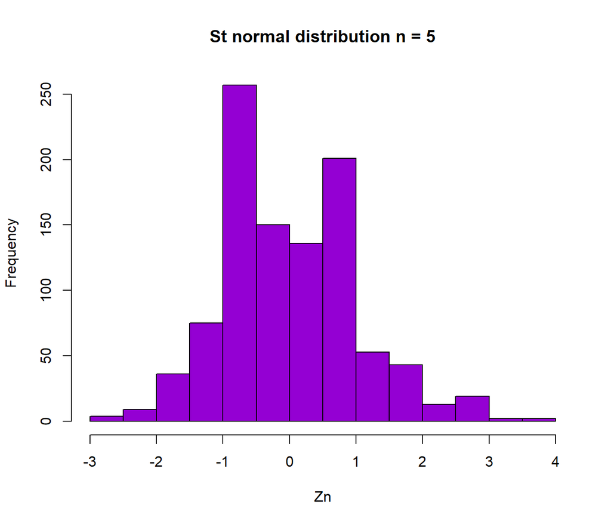

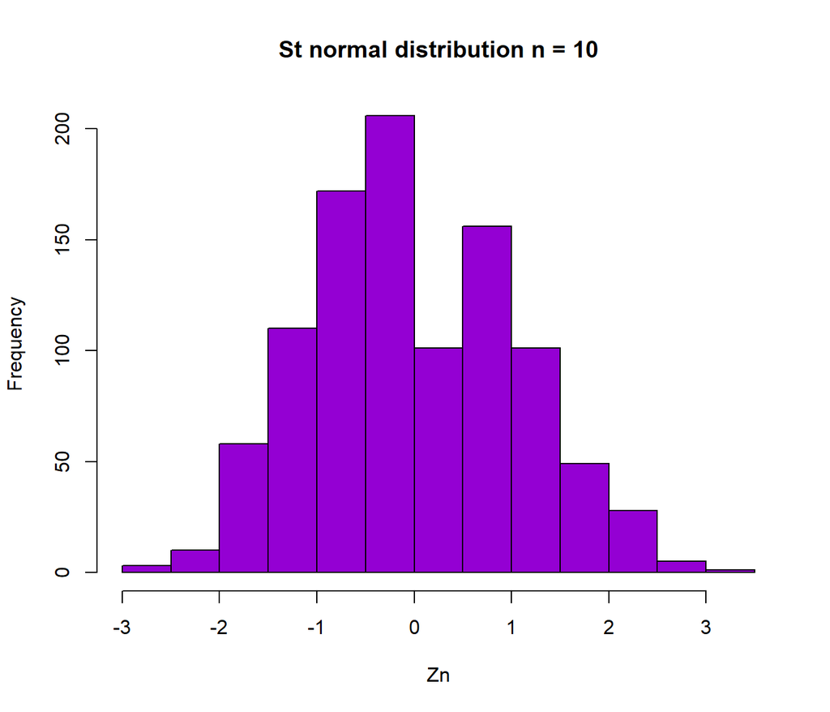

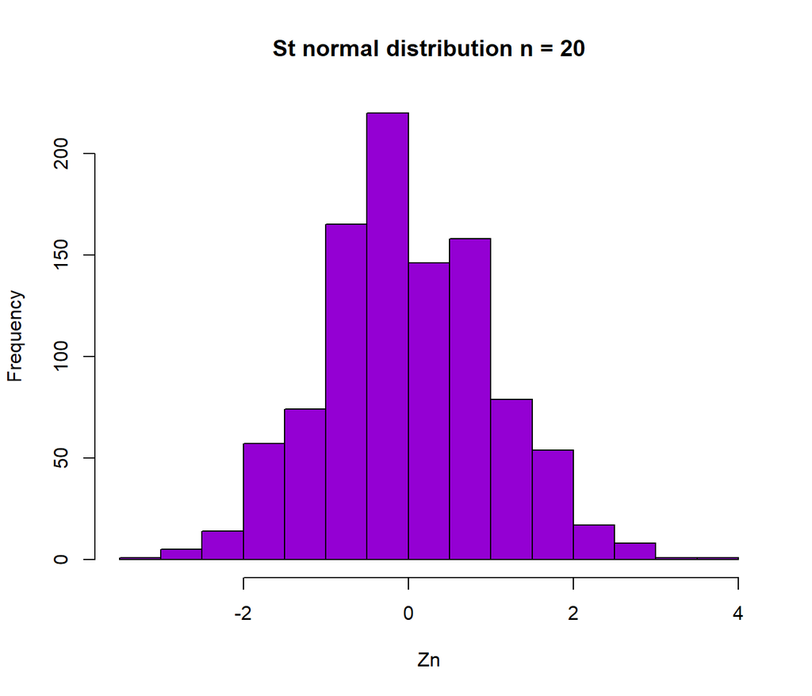

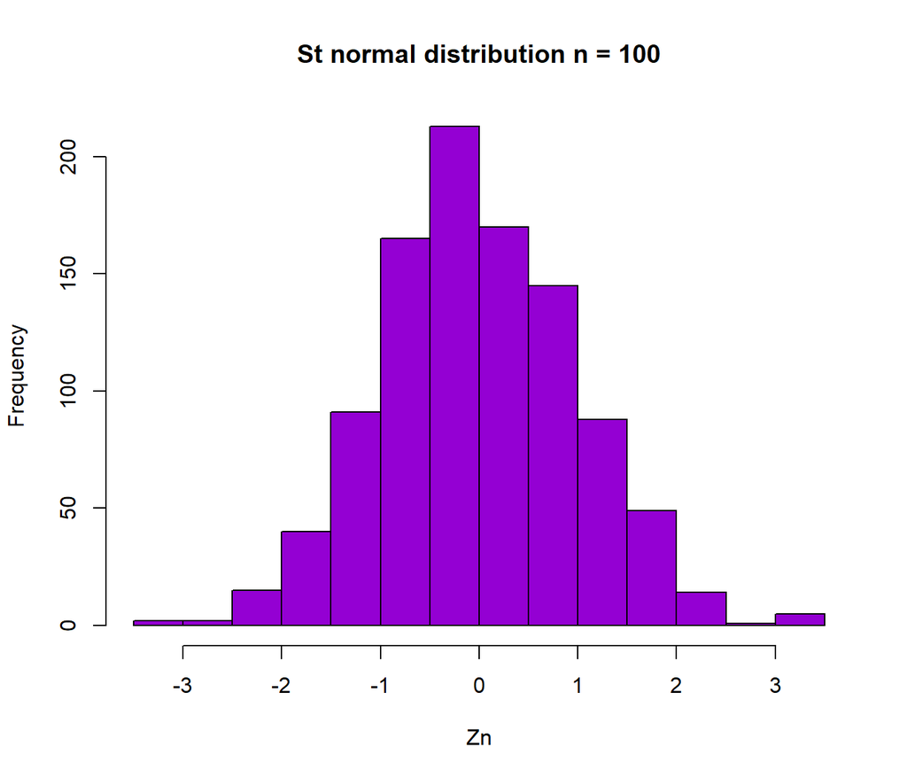

```r
n <- c(5, 10, 20, 100)
i <- 1:4
Muestra <- matrix(0L, 1000, 4)
auxiliar <- sapply(i, function(i) hist(Muestra[, i] <<- Zn2(n[i], 0.1, 15,1000), main = paste("St normal distribution n =", n[i]),
                                       xlab = "Zn",  col ="darkviolet", border = "black") )
```

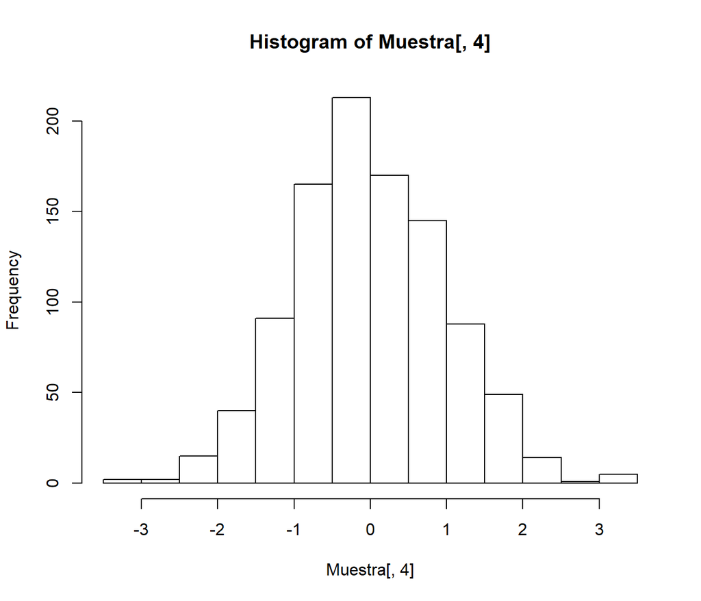

```r
View(Muestra)
hist(Muestra[, 4])
```

¿Qué observa? Explique Cuando el número de mmuestra es de 5 y diez observaciones, la función de densidad se aproxima a la de una distribución normal estandar, más sin embargo sigue sin ser la función de densidad de una normal estandar. Esto debido a que sigue presentando inconsistencias (i.e quiebres) en el centro de la distribución. Se aproxima cada vez más en las colas, pero no en el centro. La aproximación en el centro de la suceción estandarizada de binomiales mejora conforme el tamaño de la muestra crece. Para un tamaño de muestra de cien, se puede apreciar como la distribución presentada se aproxima en tanto colas y centro de densidad de una distribución a una normal estandar. En conclusión, bajo las condiciones de que la suceción de binomiales tiene momentos finitos, y dado a que la esperanza es finita existe una generadora de momentos, entonces, aplicando límite central, se observa como la media de la sucesión de variables aleatorias estandarizada converge en distribucion a una distribución límite normal estandar

4. Repita el inciso anterior para p = 0:99. Compare su resultado con lo obtenido en el inciso anterior.

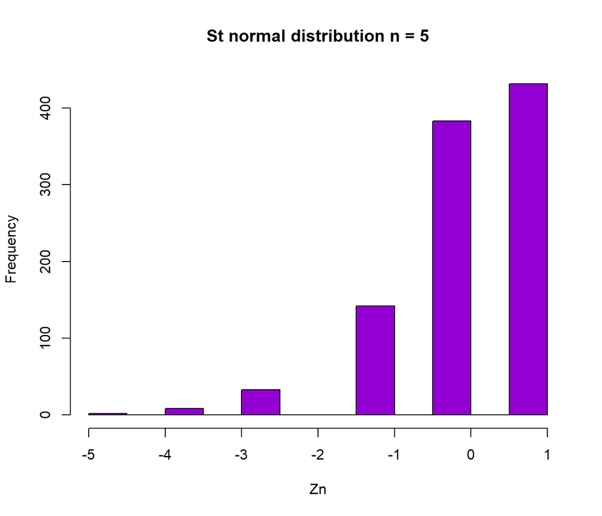

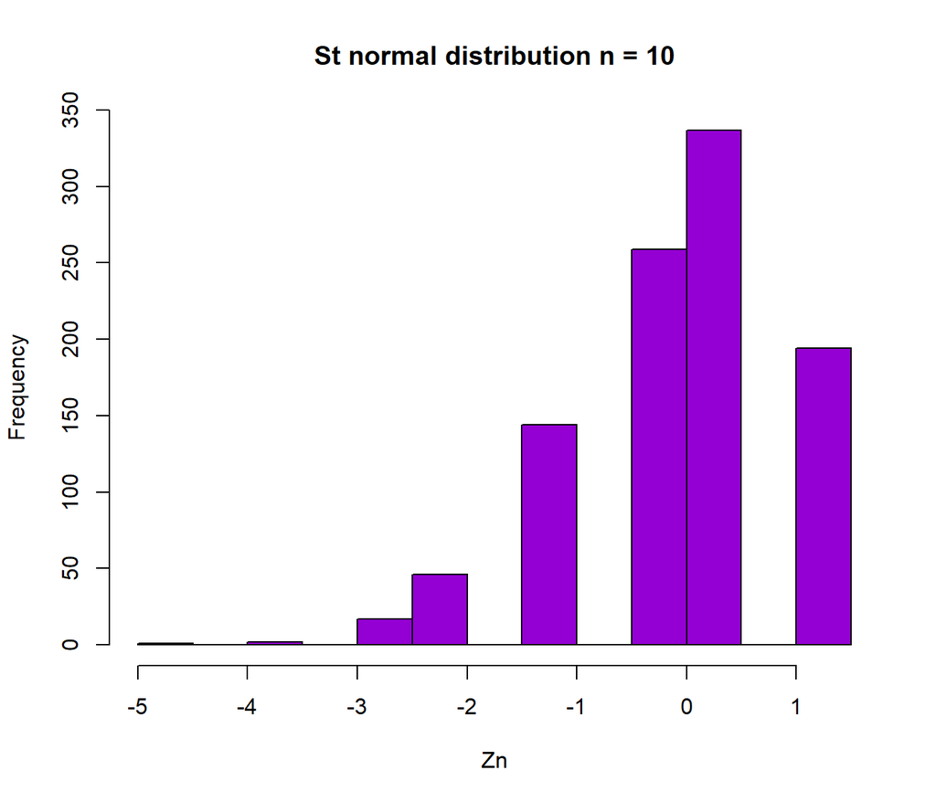

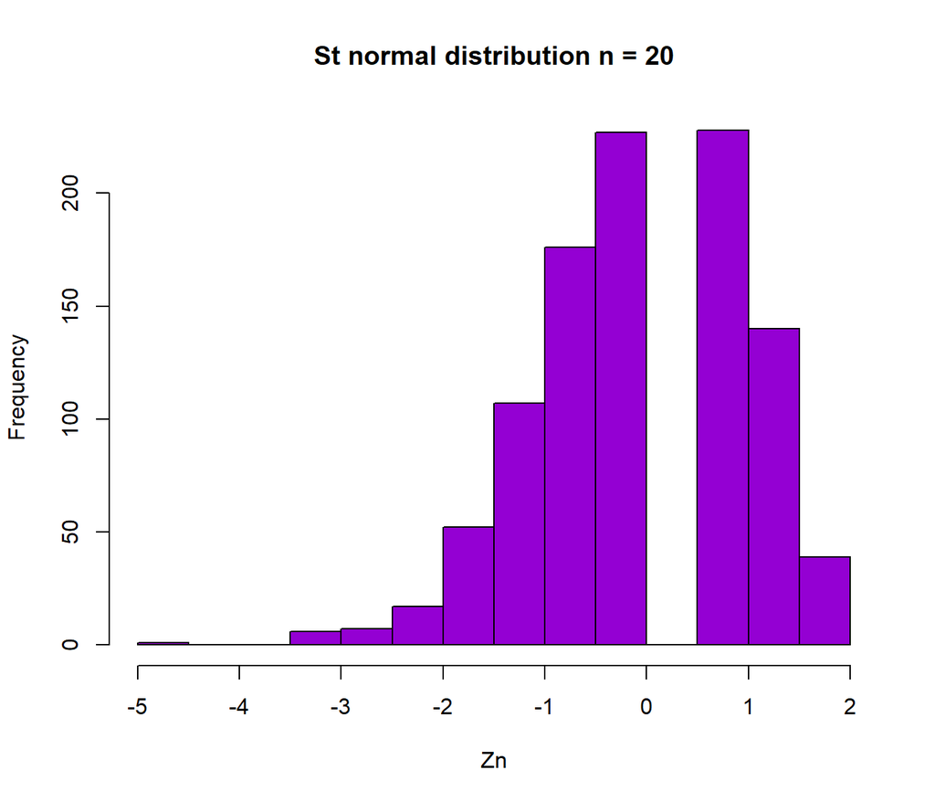

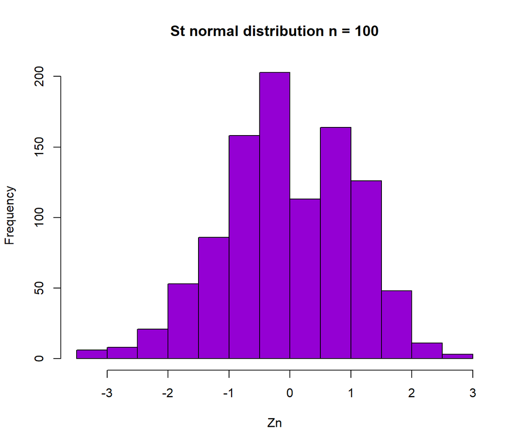

```r
n <- c(5, 10, 20, 100)
i <- 1:4
Muestra <- matrix(0L, 1000, 4)
auxiliar <- sapply(i, function(i) hist(Muestra[, i] <<- Zn2(n[i], 0.99, 15,1000), main = paste("St normal distribution n =", n[i]),
                                       xlab = "Zn",  col ="darkviolet", border = "black") )
```

Con una probabilidad de 0.99, de una distribución binomial, y con un tamaño de muestra pequeño (i.e de 5 a 20 observaciones), su función de probabilidad presenta sesgo a la izquierda (derecha para el quien lo observa), es decir, la forma de los datos se cargan hacia la izquierda (a la derecha de quien lo ve) entendiendo que la función de probabilidad no es simpetrica (asímetrica). No obstante, cuando el tamaño de la muestra incrementa se puede observar como la distribución tiene a reducir dicho sesgo. Por lo tanto, bajo el teorema del límite central, bajo ciertas condiciones al incrementar el tamaño de muestra y estandarizar los eventos binomiales, dicha distribución converge a la función de densidad de una distribución normal estandar. El sesgo desaparece en su grán mayoria, pero aún las observaciones del centro no logran aproxximar del todo bien a la normal estandar.

## EJERCICIO 4

2. Simule una sucesión de n = 1000 v.a. como arriba y calcule $S_{1000}$ para p = 0.4. Repita este proceso 100 veces y grafíque la distribución empirica de $S_{1000}$ que se obtiene de la simulacion y empalmela con la distribución asintótica teórica que obtuvo. Comente sus resultados.

```r
library("Rlab", lib.loc="~/R/win-library/3.3")
SnSimulation <-function() {
Sn <- rep(0, 1000)
i<- 1: 1000
sapply(i, function (i) {x<-rbern(1, 0.4); x2<-rbern(1, 0.4);
       if (x ==1 && x2 ==1){
         Sn[i] <<- 1 } else { Sn[i] <<- 0}})
return(apply(as.matrix(Sn), 2, sum))
}
```

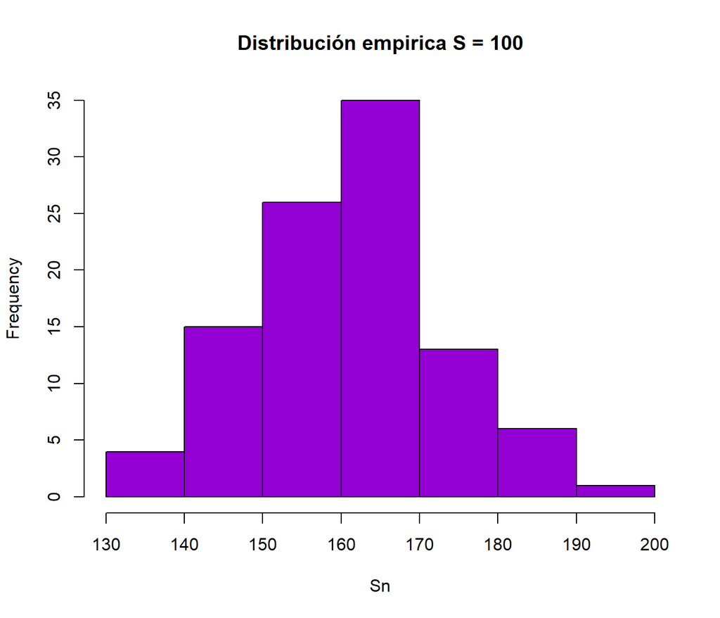

```r
n<- 1000
p<- .4
mean2 <- n*(p^2)
sd2<-sqrt(n*((p*(1-p))*(p*(1-p))))
FnEmpirica<- replicate(100, SnSimulation())

hist(FnEmpirica, main = "Distribución empirica S = 100",
     xlab = "Sn",  col ="darkviolet", border = "black")
```

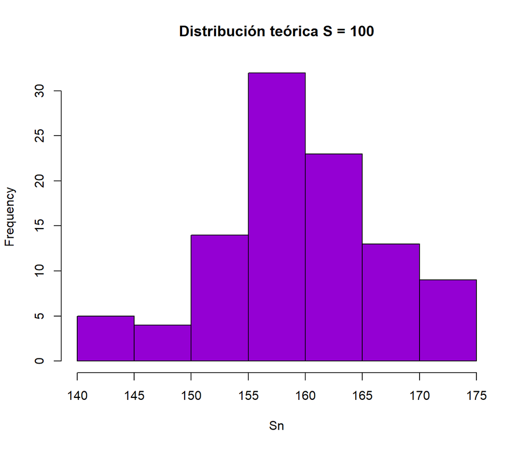

```r
FnTeorica <- replicate(100,rnorm(1, mean2 , sd2))
hist(FnTeorica,  main = "Distribución teórica S = 100",
     xlab = "Sn",  col ="darkviolet", border = "black")

library("ggplot2", lib.loc="~/R/win-library/3.3")
```

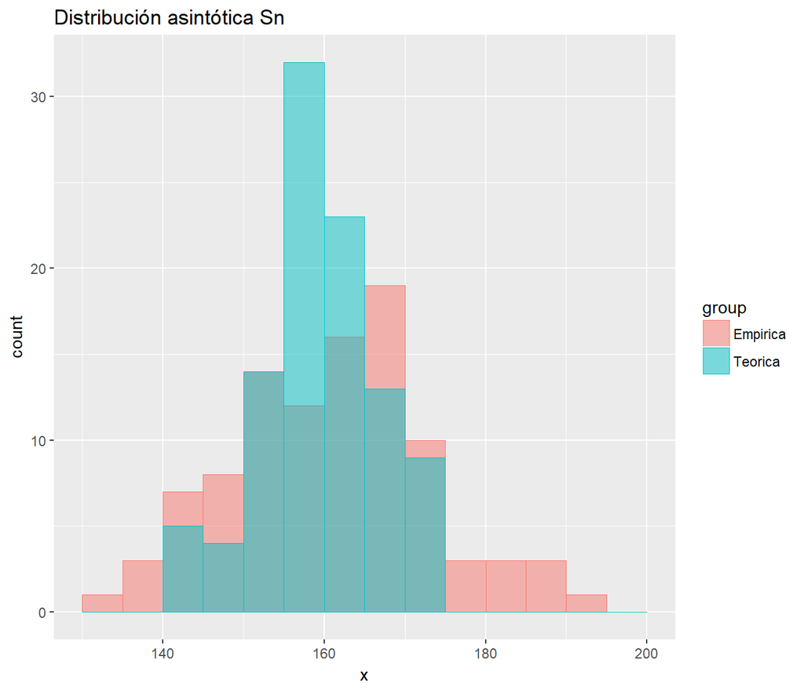

```r
# Pasando a formato data frame
geom1 <- data.frame(x = FnEmpirica, group="Empirica")
geom2 <- data.frame(x = FnTeorica, group="Teorica")


graf <- rbind(geom1, geom2)

# Histogramas de las tres simulaciones
ggplot(graf, aes(x, fill=group, colour=group)) +
  geom_histogram(aes(y=..count..), breaks=seq(130,200,5), alpha=.5,
                 position="identity", lwd=0.2) +
  ggtitle("Distribución asintótica Sn")
```